# R Notebook

Jeekin Lau

# Introduction

This is a tutorial using a very clean dataset from array generated data on a well characterized dataset that has been published already [Rose Rosette Disease Resistance Loci Detected in Two Interconnected Tetraploid Garden Rose Populations](https://www.frontiersin.org/articles/10.3389/fpls.2022.916231/full)

To download the dataset please go to https://github.com/jeekinlau/mapping_example/tree/main/data

# Import the data

Download the dataset and import the dataset into R

```r
library(mappoly)
dat = read_geno_csv(file="data/BExMG_subset.csv", ploidy = 4)
```

```
## Reading the following data:
##     Ploidy level: 4
##     No. individuals:  161
##     No. markers:  1382
##     No. informative markers:  1382 (100%)
##     ...
##     Done with reading.
##     Filtering non-conforming markers.
##     ...
##     Done with filtering.
```

# Filtering Data

## Filter by missing data

Typically, there will be many markers filtered out when filtered by marker, or by individual. Because this is a very well curated dataset, There are no markers filtered out.

```r
## Filtering dataset by marker
dat = filter_missing(input.data = dat, type = "marker",
                      filter.thres = 0.05, inter = F)
## Filtering dataset by individual
dat = filter_missing(input.data = dat, type = "individual",
                      filter.thres = 0.05, inter = F)
dat
```

```
## This is an object of class 'mappoly.data'
##     Ploidy level:                            4
##     No. individuals:                         160
##     No. markers:                             1382
##     Missing data under  prob. threshold: 1.26%
##
##     This dataset contains chromosome information.
##     ----------
##     No. of markers per dosage combination in both parents:
##     P1 P2 freq
##      0  1  108
##      0  2   30
##      0  3    9
##      1  0  108
##      1  1  120
##      1  2   91
##      1  3   42
##      1  4   10
##      2  0   32
##      2  1   75
##      2  2   97
##      2  3   60
##      2  4   29
##      3  0    7
##      3  1   40
##      3  2   77
##      3  3  167
##      3  4  116
##      4  1   10
##      4  2   36
##      4  3  118
```

## Filter by segregation distortion

Also very few markers removed due to good dataset. The figure below shows the marker types, the dosage of all the marker types, and the segregation distortion of the markers.

```r
## Filter according to segregation test
pval.bonf = 0.05/dat$n.mrk
mrks.chi.filt = filter_segregation(dat, chisq.pval.thres =  pval.bonf, inter = F)
seq.init = make_seq_mappoly(mrks.chi.filt)
seq.init
```

```
## This is an object of class 'mappoly.sequence'
##     ------------------------
##     Parameters not estimated
##     ------------------------
##     Ploidy level:       4
##     No. individuals:    160
##     No. markers:        1369
##
##     ----------
##     No. markers per sequence:
##     chrom No.mrk
##         1    166
##         2    281
##         3    163
##         4    189
##         5    151
##         6    216
##         7    203
##
##     ----------
##     No. of markers per dosage in both parents:
##    dP1 dP2 freq
##      0   1  107
##      0   2   28
##      0   3    9
##      1   0  107
##      1   1  120
##      1   2   90
##      1   3   42
##      1   4   10
##      2   0   31
##      2   1   75
##      2   2   97
##      2   3   60
##      2   4   29
##      3   0    7
##      3   1   40
##      3   2   77
##      3   3  164
##      3   4  115
##      4   1    9
##      4   2   35
##      4   3  117
```

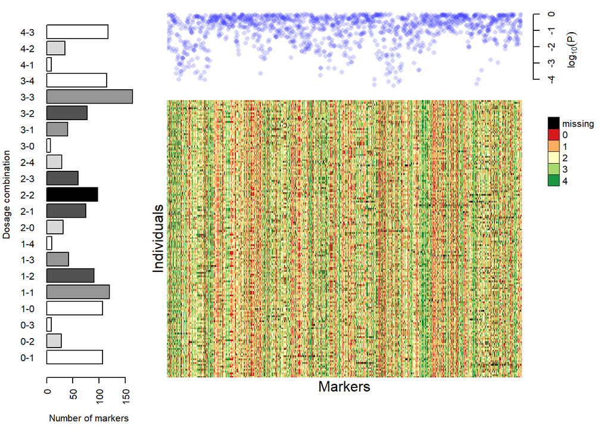

```r
plot(seq.init)
```

# Calculating recombination fractions

This step allows for the pairwise recombination fraction calculation between all markers. If you computer has multiple cores use the ‘parallel::detectCores()’ function to find out how many cores your local computer has. This step takes a while especially with a laptop with limited cores and RAM memory. (**there are tricks around this email me for alternative strategies around this**)

```r
## Accounting for recombination fractions

all.rf.pairwise = est_pairwise_rf(input.seq = seq.init, ncpus = 6)
```

```
## INFO: Using  6  CPUs for calculation.
## INFO: Done with 936396  pairs of markers
## INFO: Calculation took: 111.52 seconds
```

## Plotting RF matrix

Plotting the RF matrix shows a heat map of markers that are closely linked versus those that are far away. Naturally we see that those markers group into the 7 chromosomes of the Rose genome.

```r
mat = rf_list_to_matrix(all.rf.pairwise)
```

```
## INFO: Going singlemode. Using one CPU.
```

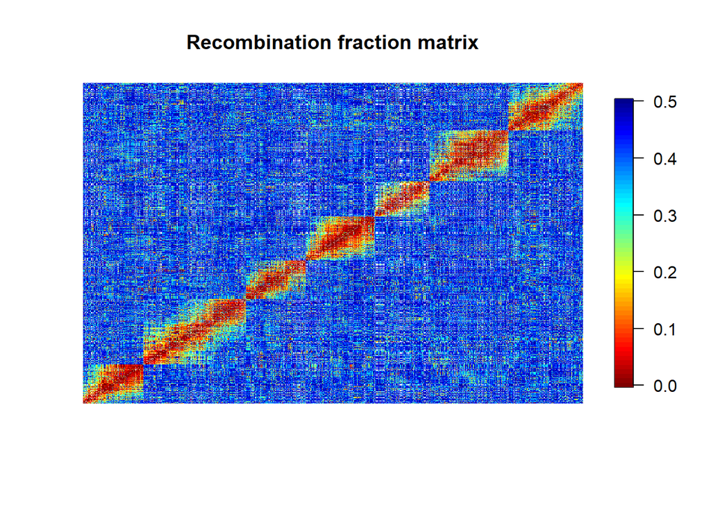

```r
plot(mat)
```

# Grouping

Next step is to group the markers into a list containing the necessary objects needed for mapping (ie markers and thier two point rf estimate and a sequence of markers). There are several ways to approach this. Below we compare the grouping using UPGMA method, genomic (physical position according to genome position), and an intersect between the two.

```r
## Getting group information (UPGMA)
grs = group_mappoly(input.mat = mat,
                     expected.groups = 7,
                     comp.mat = TRUE,
                     inter = F)
grs
```

```
##   This is an object of class 'mappoly.group'
##   ------------------------------------------
##   Criteria used to assign markers to groups:
##
##     - Number of markers:          1369
##     - Number of linkage groups:   7
##     - Number of markers per linkage groups:
##     group n.mrk
##         1   169
##         2   219
##         3   155
##         4   189
##         5   287
##         6   157
##         7   193
##   ------------------------------------------
##     1   6   5   4   2   3   7 NoChr
## 1 162   0   0   0   0   7   0     0
## 2   2 214   0   0   2   0   1     0
## 3   1   1 151   0   1   0   1     0
## 4   1   0   0 188   0   0   0     0
## 5   0   1   0   1 278   2   5     0
## 6   0   0   0   0   0 154   3     0
## 7   0   0   0   0   0   0 193     0
##   ------------------------------------------
```

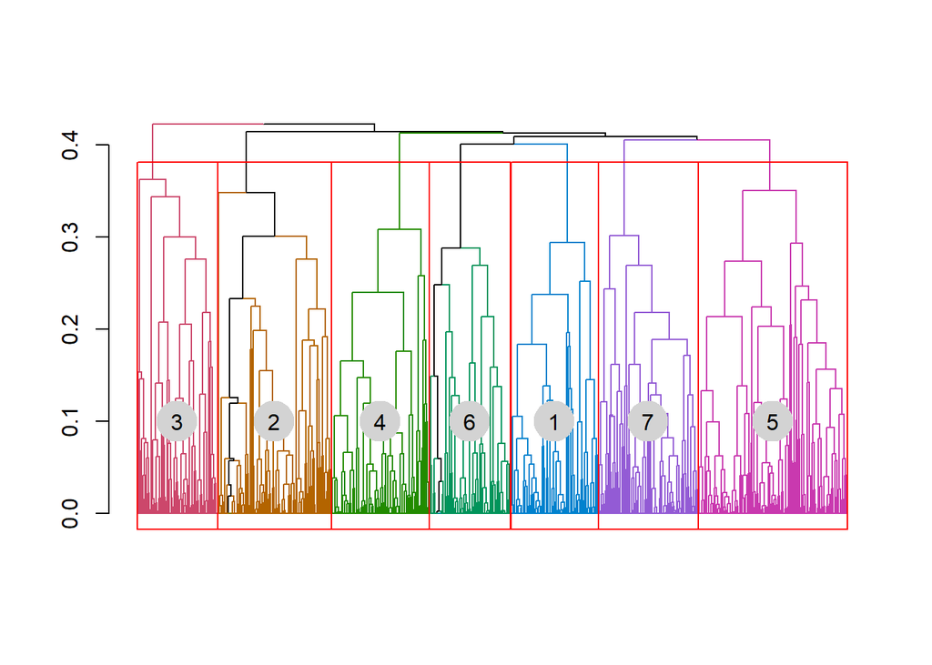

```r
plot(grs)
```

```r
## Making groups with intersection between UPGMA (rf) + genomic information (discards scaffolds)

LGS.inter=vector("list", 7)
for(j in 1:7){
  temp1 = make_seq_mappoly(grs, j, genomic.info=1)
  tpt = make_pairs_mappoly(all.rf.pairwise, input.seq = temp1)
  temp2 = rf_snp_filter(input.twopt = tpt, diagnostic.plot = FALSE)
  tpt2 = make_pairs_mappoly(tpt, input.seq = temp2)
  LGS.inter[[as.numeric(names(table(temp2$chrom))[which.max(table(temp2$chrom))])]] = list(seq = temp2, tpt = tpt2)
}
# ## Getting rf matrices
# rfs.inter = lapply(LGS.inter, function(x) rf_list_to_matrix(x$tpt))
# ## Plotting rf matrices
# #png(file="UPGMA_Genomic.png", width = 1600, height = 800)
# par(mfrow=c(2,4))
# for (i in 1:length(rfs.inter)){plot(rfs.inter[[i]])}
# mtext("Linkage groups with\nUPGMA + genomic information\n(discarding scaffolds)", cex = 2, side = 3, line = -63, at = 0.88, outer = TRUE)
# par(mfrow=c(1,1))
# #dev.off()

## Making groups only with genomic information (tends to bring more markers, but also discards scaffolds)
LGS.genomic = vector("list", 7)
for (i in 1:7){
  tempseq1 = make_seq_mappoly(dat, arg = paste0("seq",i), genomic.info = 1)
  mrks = intersect(tempseq1$seq.mrk.names, seq.init$seq.mrk.names)
  tempseq = make_seq_mappoly(dat, arg = mrks)
  temptpt = make_pairs_mappoly(all.rf.pairwise, input.seq = tempseq)
  rffilt = rf_snp_filter(input.twopt = temptpt, diagnostic.plot = FALSE)
  temptpt2 = make_pairs_mappoly(temptpt, input.seq = rffilt)
  LGS.genomic[[as.numeric(unique(rffilt$chrom))]] = list(seq = rffilt, tpt = temptpt2)
}
# ## Getting rf matrices
# rfs.genomic = lapply(LGS.genomic, function(x) rf_list_to_matrix(x$tpt))
# ## Plotting rf matrices
# #png(file="Genomic.png", width = 1600, height = 800)
# par(mfrow=c(2,4))
# for (i in 1:length(rfs.genomic)){plot(rfs.genomic[[i]])}
# mtext("Linkage groups with\ngenomic information\n(discarding scaffolds)", cex = 2, side = 3, line = -63, at = 0.88, outer = TRUE)
# par(mfrow=c(1,1))
# #dev.off()

## Making groups with UPGMA (rf) information (includes scaffolds)
LGS.upgma=vector("list", 7)
for(j in 1:7){
  temp1 = make_seq_mappoly(grs, j)
  tpt = make_pairs_mappoly(all.rf.pairwise, input.seq = temp1)
  temp2 = rf_snp_filter(input.twopt = tpt, diagnostic.plot = FALSE)
  tpt2 = make_pairs_mappoly(tpt, input.seq = temp2)
  LGS.upgma[[as.numeric(names(table(temp2$chrom))[which.max(table(temp2$chrom))])]] = list(seq = temp2, tpt = tpt2)
}
# ## Getting rf matrices
# rfs = lapply(LGS.upgma, function(x) rf_list_to_matrix(x$tpt))
# ## Plotting rf matrices
# #png(file="UPGMA.png", width = 1600, height = 800)
# par(mfrow=c(2,4))
# for (i in 1:length(rfs)){plot(rfs[[i]])}
# mtext("Linkage groups with\nUPGMA information\n(including scaffolds)", cex = 2, side = 3, line = -63, at = 0.88, outer = TRUE)
# par(mfrow=c(1,1))
# #dev.off()

## Comparing number of markers in each group
comp = data.frame(UPGMA_Genomic = unlist(lapply(LGS.inter, function(x) length(x$seq$seq.num))),
                  Genomic = unlist(lapply(LGS.genomic, function(x) length(x$seq$seq.num))),
                  UPGMA = unlist(lapply(LGS.upgma, function(x) length(x$seq$seq.num))))
comp
```

```
##   UPGMA_Genomic Genomic UPGMA
## 1           154     158   160
## 2           264     268   272
## 3           146     156   149
## 4           180     181   180
## 5           144     144   148
## 6           203     205   208
## 7           183     192   183
```

We see that all three are very similar and for the purpose of this example lets just take the upgma grouping and run with that.

```r
LGS<-LGS.upgma
```

# HMM chain

The HMM chain is used to order the markers. Below is a example of just ordering one chromosome. Later we will show how to parallelize this task by chromosome. (NOTE the map is only running quickly here because of the small number of markers and the good quality of the data)

```r
single_chrom <- est_rf_hmm_sequential(input.seq = LGS[[1]]$seq,
                               start.set = 3,
                               thres.twopt = 10,
                               thres.hmm = 50,
                               extend.tail = 30,
                               twopt = LGS[[1]]$tpt,
                               verbose = TRUE,
                               phase.number.limit = 20,
                               sub.map.size.diff.limit = 5)
```

```
## Number of markers: 160
```

```
## ════════════════════════════════════════════════════════════ Initial sequence ══
```

```
## 3 markers...
## •    Trying sequence: 1 2 3 :
##        2 phase(s): . .
```

```
## ══════════════════════════════════════════════════ Done with initial sequence ══
```

```
## Making 'reestimate.single.ph.configuration = TRUE' to use map expansion
```

[output not shown]

[output cut: 102 more lines]

[output not shown]

```
## ══════════════════════════════════ Reestimating final recombination fractions ══
```

```
## Markers in the initial sequence: 160
## Mapped markers                  : 159 (99.4%)
```

```
## ════════════════════════════════════════════════════════════════════════════════
```

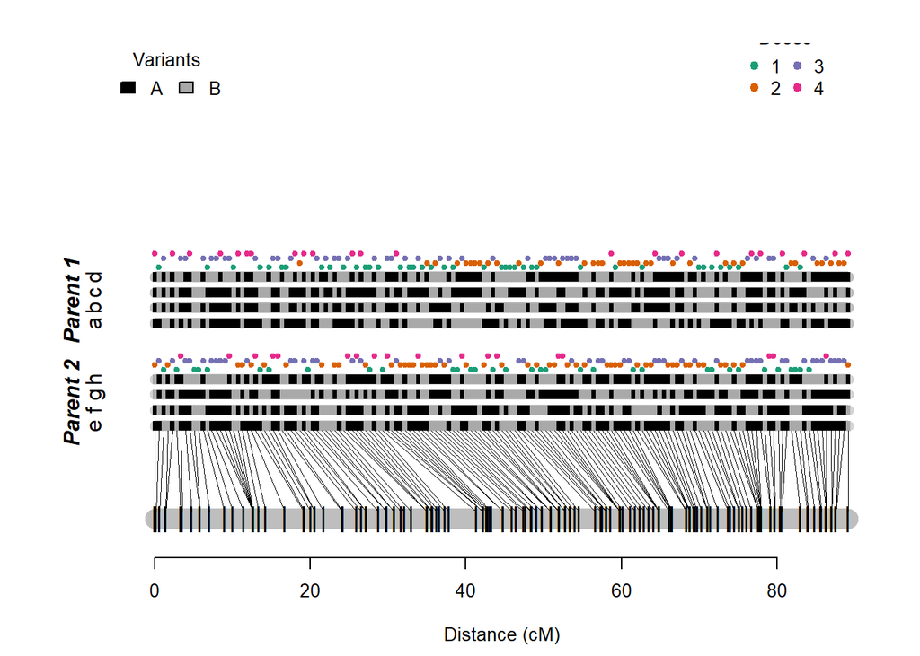

```r
plot(single_chrom)
```

## Parallel construction of all 7 LGs

```r
## Performing parallel computation of hidden markov
phasing_and_hmm_rf <- function(X){
  fl <- paste0("output_map_ch_", unique(X$seq$chrom), ".txt")
  sink(fl)
  map <- est_rf_hmm_sequential(input.seq = X$seq,
                               start.set = 3,
                               thres.twopt = 10,
                               thres.hmm = 50,
                               extend.tail = 30,
                               twopt = X$tpt,
                               verbose = TRUE,
                               phase.number.limit = 20,
                               sub.map.size.diff.limit = 5)
  sink()
  return(map)
}


# 5% genotyping error
my.error.func<-function(X){
  x<-est_full_hmm_with_global_error(input.map = X,
                                    error = 0.05,
                                    tol = 10e-4,
                                    verbose = FALSE)
  return(x)
}
#upgma
#hidden markov based off physical location
cl <- parallel::makeCluster(7)
parallel::clusterEvalQ(cl, require(mappoly))
```

```
## [[1]]
## [1] TRUE
##
## [[2]]
## [1] TRUE
##
## [[3]]
## [1] TRUE
##
## [[4]]
## [1] TRUE
##
## [[5]]
## [1] TRUE
##
## [[6]]
## [1] TRUE
##
## [[7]]
## [1] TRUE
```

```r
parallel::clusterExport(cl, "dat")
MAPs <- parallel::parLapply(cl,LGS, phasing_and_hmm_rf)
parallel::stopCluster(cl)

plot_map_list(MAPs, col = "ggstyle")
# account for error
cl <- parallel::makeCluster(7)
parallel::clusterEvalQ(cl, require(mappoly))
```

```
## [[1]]
## [1] TRUE
##
## [[2]]
## [1] TRUE
##
## [[3]]
## [1] TRUE
##
## [[4]]
## [1] TRUE
##
## [[5]]
## [1] TRUE
##
## [[6]]
## [1] TRUE
##
## [[7]]
## [1] TRUE
```

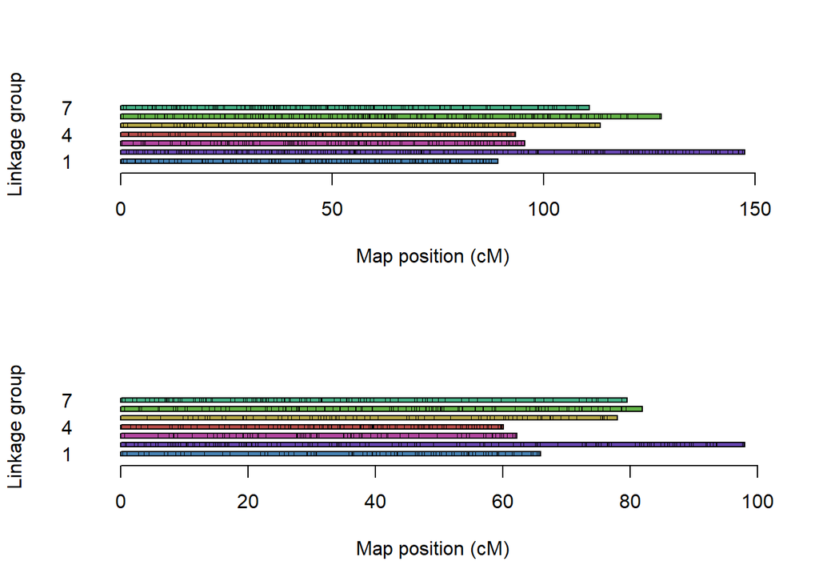

```r
parallel::clusterExport(cl, "dat")
MAPs.err <- parallel::parLapply(cl,MAPs,my.error.func)
parallel::stopCluster(cl)

par(mfrow=c(2,1))
plot_map_list(MAPs, col = "ggstyle")
plot_map_list(MAPs.err, col = "ggstyle")
```

After constructing the maps a 5% global error rate is applied to the chain to allow for the chain to make small changes that correct for possible genotyping error. The difference is seen the the picture above where the second map is shorter indicating a better map.

# Genotypic probabilites for use in QTL mapping

```r
genoprob.err <- vector("list", 7)
for(i in 1:7)
   genoprob.err[[i]] <- calc_genoprob_error(input.map = MAPs.err[[i]], error = 0.05)
```

```
## Ploidy level:4
## Number of individuals:160
##  ..................................................
##  ..................................................
##  ..................................................
##  ..........
## Ploidy level:4
## Number of individuals:160
##  ..................................................
##  ..................................................
##  ..................................................
##  ..........
## Ploidy level:4
## Number of individuals:160
##  ..................................................
##  ..................................................
##  ..................................................
##  ..........
## Ploidy level:4
## Number of individuals:160
##  ..................................................
##  ..................................................
##  ..................................................
##  ..........
## Ploidy level:4
## Number of individuals:160
##  ..................................................
##  ..................................................
##  ..................................................
##  ..........
## Ploidy level:4
## Number of individuals:160
##  ..................................................
##  ..................................................
##  ..................................................
##  ..........
## Ploidy level:4
## Number of individuals:160
##  ..................................................
##  ..................................................
##  ..................................................
##  ..........
```

```r
saveRDS(genoprob.err, file="genoprob.err.RDS")
```